# Prediction Assignment Writeup

We are going to predict the manner in which people do some exercises. We are going to test this analyzing the “classe” variable in the training set.  
We are going to describe how we built our model.

## Prerrequisites

First of all we are going to install the libraries we are going to use in the development.

```r
library(caret)
library(rpart)
library(rattle) #Para el decision tree.
```

We load the train and test sets.

```r
training_set <- read.csv("pml-training.csv")
testing_set <- read.csv("pml-testing.csv")
```

We split the training set using 70 % only for training and 30 % for test.  
The goal field is “classe” which contains the different ways to do the exercise.

```r
splittedTrain  <- createDataPartition(training_set$classe, p=0.7, list=FALSE)
```

We split the training set in two sets to do the predictions.

```r
train_splittedTrain <- training_set[splittedTrain,]
test_splittedTrain <- training_set[-splittedTrain,]
```

And we can see the number of observations and variables of each.

```r
dim(train_splittedTrain)
```

```
## [1] 13737   160
```

```r
dim(test_splittedTrain)
```

```
## [1] 5885  160
```

We calculate the zero and near Zero-variance variables, (they only have a single unique value).  
This may cause that the model crashed or the fit was unstable.

```r
nzv_delete <- nearZeroVar(train_splittedTrain)

#We build a new model without those fields.
filtered_inTrain <- train_splittedTrain[,-nzv_delete]
```

Now we have less variables.

```r
dim(filtered_inTrain)
```

```
## [1] 13737   100
```

And we remove the fields which have a big number of NAs.

```r
NA_values <- sapply(filtered_inTrain, function(x) mean(is.na(x))) > 0.95
filtered_inTrain_withoutNA <- filtered_inTrain[,NA_values == FALSE]
```

We now only have 59 fields.

```r
dim(filtered_inTrain_withoutNA)
```

```
## [1] 13737    59
```

We remove the first five fields because they are for identification.

```r
filtered_inTrain_withoutNA_withoutIdentif <- filtered_inTrain_withoutNA[,-(1:5)]
```

We have 54 variables now.

```r
dim(filtered_inTrain_withoutNA_withoutIdentif)
```

```
## [1] 13737    54
```

We copy the data frame to a new data frame to work with it.

```r
work_data <- filtered_inTrain_withoutNA_withoutIdentif
```

## Methods

The target variable is cualitative then this is a clasification question with more than two solutions. Then we are going to use methods for clasification problems.  
The most common measure of classifier quality is accuracy. We are going measure this with the confussion matrix.

## A) Decision tree.

This can be used to quickly predict categorical outcomes.

```r
set.seed(33) #We use seed for reproducibility.
```

We build a decision tree with rpart(). We use the class method because the target variable is a factor.

```r
tree_model <- rpart(classe~.,data=work_data, method = "class")
```

We plot the tree with rattle library.

[figure not shown]

```r
fancyRpartPlot(tree_model)
```

Prediction over data test.

```r
predict_with_Decision_Tree <- predict(tree_model, newdata = test_splittedTrain, type = "class")
```

We are to obtain the confussion matrix.

```r
confussion_Matrix_DecTree <- confusionMatrix(predict_with_Decision_Tree, test_splittedTrain$classe)
confussion_Matrix_DecTree
```

```
## Confusion Matrix and Statistics
##
##           Reference
## Prediction    A    B    C    D    E
##          A 1536  178   35   48   10
##          B   28  710   67   25   14
##          C   44   97  742   64   64
##          D   57  124  176  751   91
##          E    9   30    6   76  903
##
## Overall Statistics
##
##                Accuracy : 0.7888
##                  95% CI : (0.7781, 0.7992)
##     No Information Rate : 0.2845
##     P-Value [Acc > NIR] : < 2.2e-16
##
##                   Kappa : 0.7325
##
##  Mcnemar's Test P-Value : < 2.2e-16
##
## Statistics by Class:
##
##                      Class: A Class: B Class: C Class: D Class: E
## Sensitivity            0.9176   0.6234   0.7232   0.7790   0.8346
## Specificity            0.9356   0.9718   0.9446   0.9090   0.9748
## Pos Pred Value         0.8500   0.8412   0.7339   0.6264   0.8818
## Neg Pred Value         0.9662   0.9149   0.9417   0.9545   0.9632
## Prevalence             0.2845   0.1935   0.1743   0.1638   0.1839
## Detection Rate         0.2610   0.1206   0.1261   0.1276   0.1534
## Detection Prevalence   0.3071   0.1434   0.1718   0.2037   0.1740
## Balanced Accuracy      0.9266   0.7976   0.8339   0.8440   0.9047
```

And we plot the confussion matrix.

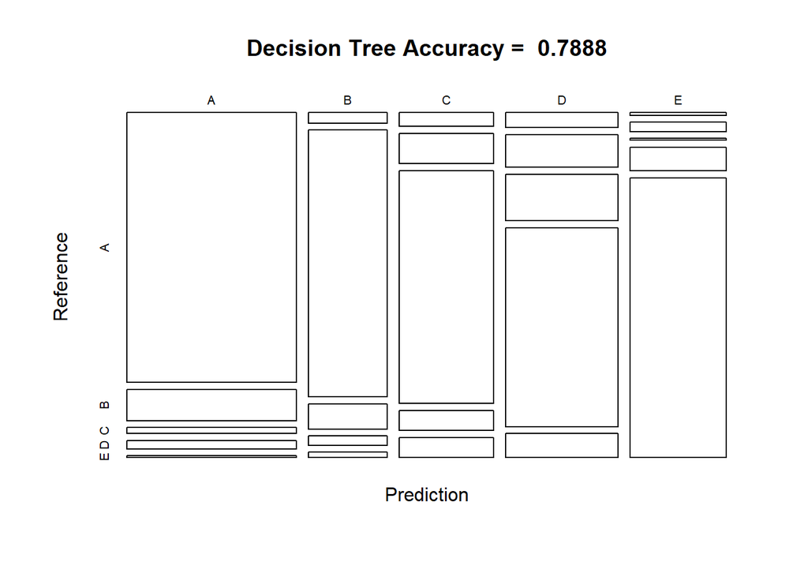

```r
plot(confussion_Matrix_DecTree$table, col = confussion_Matrix_DecTree$byClass,
     main = paste("Decision Tree Accuracy = ", round(confussion_Matrix_DecTree$overall['Accuracy'],4)))
```

## B) Random Forests with 5 folds in cross-validation

```r
set.seed(33)
rf_model<-train(classe~.,data=work_data,method="rf", trControl=trainControl(method="cv",number=5), prox=TRUE,allowParallel=TRUE)
print(rf_model)
```

```
## Random Forest
##
## 13737 samples
##    53 predictor
##     5 classes: 'A', 'B', 'C', 'D', 'E'
##
## No pre-processing
## Resampling: Cross-Validated (5 fold)
## Summary of sample sizes: 10989, 10991, 10989, 10988, 10991
## Resampling results across tuning parameters:
##
##   mtry  Accuracy   Kappa
##    2    0.9935209  0.9918043
##   27    0.9967968  0.9959484
##   53    0.9938851  0.9922647
##
## Accuracy was used to select the optimal model using the largest value.
## The final value used for the model was mtry = 27.
```

```r
rf_model$finalModel
```

```
##
## Call:
##  randomForest(x = x, y = y, mtry = param$mtry, proximity = TRUE,      allowParallel = TRUE)
##                Type of random forest: classification
##                      Number of trees: 500
## No. of variables tried at each split: 27
##
##         OOB estimate of  error rate: 0.23%
## Confusion matrix:
##      A    B    C    D    E  class.error
## A 3904    1    0    0    1 0.0005120328
## B    4 2650    4    0    0 0.0030097818
## C    0    4 2391    1    0 0.0020868114
## D    0    0   10 2241    1 0.0048845471
## E    0    0    0    5 2520 0.0019801980
```

Prediction over data test.

```r
predict_with_Random_Forest <- predict(rf_model, newdata=test_splittedTrain)
confussion_Matrix_RForest <- confusionMatrix(predict_with_Random_Forest, test_splittedTrain$classe)
confussion_Matrix_RForest
```

```
## Confusion Matrix and Statistics
##
##           Reference
## Prediction    A    B    C    D    E
##          A 1674    1    0    0    0
##          B    0 1138    0    0    0
##          C    0    0 1026    3    0
##          D    0    0    0  961    0
##          E    0    0    0    0 1082
##
## Overall Statistics
##
##                Accuracy : 0.9993
##                  95% CI : (0.9983, 0.9998)
##     No Information Rate : 0.2845
##     P-Value [Acc > NIR] : < 2.2e-16
##
##                   Kappa : 0.9991
##
##  Mcnemar's Test P-Value : NA
##
## Statistics by Class:
##
##                      Class: A Class: B Class: C Class: D Class: E
## Sensitivity            1.0000   0.9991   1.0000   0.9969   1.0000
## Specificity            0.9998   1.0000   0.9994   1.0000   1.0000
## Pos Pred Value         0.9994   1.0000   0.9971   1.0000   1.0000
## Neg Pred Value         1.0000   0.9998   1.0000   0.9994   1.0000
## Prevalence             0.2845   0.1935   0.1743   0.1638   0.1839
## Detection Rate         0.2845   0.1934   0.1743   0.1633   0.1839
## Detection Prevalence   0.2846   0.1934   0.1749   0.1633   0.1839
## Balanced Accuracy      0.9999   0.9996   0.9997   0.9984   1.0000
```

We plot the confussion matrix.

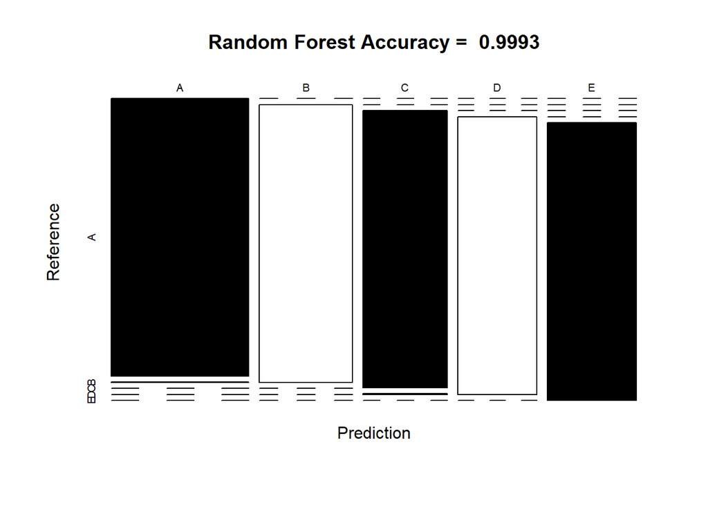

```r
plot(confussion_Matrix_RForest$table, col = confussion_Matrix_RForest$byClass,
     main = paste("Random Forest Accuracy = ", round(confussion_Matrix_RForest$overall['Accuracy'],4)))
```

## Conclussions

We can see random forests method is better to predict outcomes and obtain a fitter values for “classe” attribute.